# Commonality analysis for genes, mental health, social demographic lifestyle developmental and sets of brain features

Yue Wang and Narun P

25 Sep, 2023

```
##          used (Mb) gc trigger (Mb) limit (Mb) max used (Mb)
## Ncells 532870 28.5    1187782 63.5         NA   669405 35.8
## Vcells 989573  7.6    8388608 64.0     131072  1851525 14.2
```

## 0.1 Note

Here we the ABCD release 4.0 data-set

This file has all the linear mixed models with genes predictions as a variable. The reasons in doing this is that the number of observations in the genes data is substantially less than all the other variables. To be more specific: we have around 5,000 observations in genes data and 11,000 observations in mental health, social demographic lifestyle developmental and sets of brain features.

# 1 Setting up the environments

## 1.1 Loading libraries

The following libraries and default settings were used during the analysis:

```r
options(scipen = 999)
#library("sva")
library(tidyverse)
library("tidymodels")
```

```r
##parallel map
library(partR2)
library(lme4)
library(yhat)
library(ggtext)
library(ggpubr)
library(cowplot)
library(partR2)
library(lme4)
library(yhat)
library("VennDiagram")
## library to tidy up the linear mixed models
library(sjPlot)
theme_set(theme_bw() + theme(panel.grid = element_blank()))
## parallel processing number of cores register
all_cores <- parallel::detectCores(logical = FALSE) - 5

doParallel::registerDoParallel(cores = all_cores)
```

## 1.2 Setting up the path

We first loaded all of the relevant data files (not shown here as they refer to local directories):

# 2 Data Preparation

## 2.1 load fitted gfactors from brain scan and psychopathology

### 2.1.1 load the mental health predicted results

```r
psy_pred <- readRDS(paste0(scriptfold,"Common_psy_gene_brain_all/saved_outputs/psychopathology_pls_pred_2.0.RData"))
```

### 2.1.2 Load in genetics related to cognition predicted results

```r
genetics_cog <- readRDS(paste0(scriptfold,'genetics_psychopathology_common_scan_all_scripts/psychopathology_cog_gene_pred_residual', '.RData'))
```

### 2.1.3 load the computed gfactor

```r
gfactor_list <- readRDS(paste0(scriptfold,"genetics_psychopathology_common_scan_all_scripts/gfactor_scale_seperate.RData"))
```

## 2.2 process loaded genes and mental health model predictions

Be careful with what site you choose.

```r
gfactor_baselie_test <- map(gfactor_list,"output_test_baseline")
gfactor_followup_test <- map(gfactor_list,"output_test_followup")
```

```r
subj_info <- c("SUBJECTKEY","SITE_ID_L","EVENTNAME")
```

Functions to process the loaded prediction results.

```r
pred_processing <- function(baseline_pred, followup_pred, baseline_table, followup_table,pred_name){
  names_vec <- c(subj_info,pred_name)

  baseline_subj_info <- baseline_table %>% select(all_of(subj_info))
  baseline_pred_vec <- baseline_pred %>% select(model_predict)
  baseline_output <- bind_cols(baseline_subj_info,baseline_pred_vec)
  names(baseline_output) <- names_vec

  followup_subj_info <- followup_table %>% select(all_of(subj_info))
  followup_pred_vec <- followup_pred %>% select(model_predict)
  followup_output <- bind_cols(followup_subj_info,followup_pred_vec)
  names(followup_output) <- names_vec

  output_all <- bind_rows(baseline_output,followup_output)
  return(list(baseline_output = baseline_output,
              followup_output = followup_output))
}
```

Combine all the subject information and prediction together and change the names.

```r
processed_psy_results <- pmap(list(psy_pred[["baseline_test_pred"]],
                                   psy_pred[["baseline_test_data"]],
                                  psy_pred[["followup_test_pred"]],
                                  psy_pred[["followup_test_data"]]),
                             ~pred_processing(baseline_pred=..1,
                                              followup_pred=..3,
                                              baseline_table=..2,
                                              followup_table=..4,
                                              pred_name="psychopathology_pls"))
```

```r
site_char <- names(processed_psy_results)
```

### 2.2.1 prepocessing genetics prediction results

load in family index data

```r
ACS <-read_csv(paste0(datafolder,"ACSPSW03_DATA_TABLE.csv"))
#knitr::kable(glimpse(ACS))

#race_ethnicity
#1 = White; 2 = Black; 3 = Hispanic; 4 = Asian; 5 = Other

# guardian-report relationship
# Relationship of the participant in his or her family
# 0 = single; 1 = sibling; 2 = twin; 3 = triplet
# ACS %>% count(REL_RELATIONSHIP)

ACSselected <- ACS %>%
  select(SUBJECTKEY, EVENTNAME, SEX, INTERVIEW_AGE, RACE_ETHNICITY,
                              REL_FAMILY_ID, ACS_RAKED_PROPENSITY_SCORE) %>%
  mutate(RACE_ETHNICITY = recode_factor(as.factor(RACE_ETHNICITY),
                `1` = "White", `2` = "Black", `3` = "Hispanic", `4` = "Asian", `5` = "Other",
                .default = "White")) %>%
  mutate(SEX = as.factor(SEX)) %>%
  mutate(REL_FAMILY_ID = as.factor(REL_FAMILY_ID))

ACSselected %>%
 filter(EVENTNAME =="baseline_year_1_arm_1") %>%
 skimr::skim()
```

Data summary

| Name | Piped data |
| --- | --- |
| Number of rows | 11876 |
| Number of columns | 7 |
| _______________________ |  |
| Column type frequency: |  |
| character | 2 |
| factor | 3 |
| numeric | 2 |
| ________________________ |  |
| Group variables | None |

**Variable type: character**

| skim_variable | n_missing | complete_rate | min | max | empty | n_unique | whitespace |
| --- | --- | --- | --- | --- | --- | --- | --- |
| SUBJECTKEY | 0 | 1 | 12 | 16 | 0 | 11876 | 0 |
| EVENTNAME | 0 | 1 | 21 | 21 | 0 | 1 | 0 |

**Variable type: factor**

| skim_variable | n_missing | complete_rate | ordered | n_unique | top_counts |
| --- | --- | --- | --- | --- | --- |
| SEX | 0 | 1 | FALSE | 2 | M: 6196, F: 5680 |
| RACE_ETHNICITY | 2 | 1 | FALSE | 5 | Whi: 6180, His: 2411, Bla: 1784, Oth: 1247 |
| REL_FAMILY_ID | 0 | 1 | FALSE | 9854 | 373: 5, 749: 4, 11: 3, 400: 3 |

**Variable type: numeric**

| skim_variable | n_missing | complete_rate | mean | sd | p0 | p25 | p50 | p75 | p100 | hist |
| --- | --- | --- | --- | --- | --- | --- | --- | --- | --- | --- |
| INTERVIEW_AGE | 0 | 1 | 118.98 | 7.50 | 107.00 | 112.00 | 119.00 | 126.00 | 133.00 | ▇▆▆▆▆ |
| ACS_RAKED_PROPENSITY_SCORE | 0 | 1 | 691.34 | 350.98 | 161.36 | 449.35 | 619.31 | 821.74 | 1778.92 | ▅▇▂▂▁ |

```r
ACSselected_baseline <- ACSselected %>%
                        filter(EVENTNAME =="baseline_year_1_arm_1")%>%
                        select(SUBJECTKEY,REL_FAMILY_ID)

ACSselected_followup <- ACSselected %>%
                        filter(EVENTNAME =="1_year_follow_up_y_arm_1")%>%
                        select(SUBJECTKEY,REL_FAMILY_ID)
```

Process the genes data.

```r
genetics_cog_baseline_pred <-genetics_cog[["baseline_test_pred"]]
genetics_cog_baseline_table <-genetics_cog[["baseline_test_data"]]

genetics_cog_followup_pred <- genetics_cog[["followup_test_pred"]]
genetics_cog_followup_data <- genetics_cog[["followup_test_data"]]


pred_processing_gene <- function(baseline_pred, followup_pred, baseline_table, followup_table,pred_name){
  names_vec <- c(c("SUBJECTKEY","SITE_ID_L"),pred_name)

  baseline_subj_info <- baseline_table %>% select(all_of(c("SUBJECTKEY","SITE_ID_L")))
  baseline_pred_vec <- baseline_pred %>% select(model_predict)
  baseline_output <- bind_cols(baseline_subj_info,baseline_pred_vec)
  names(baseline_output) <- names_vec

  followup_subj_info <- followup_table %>% select(all_of(c("SUBJECTKEY","SITE_ID_L")))
  followup_pred_vec <- followup_pred %>% select(model_predict)
  followup_output <- bind_cols(followup_subj_info,followup_pred_vec)
  names(followup_output) <- names_vec

  output_all <- bind_rows(baseline_output,followup_output)
  return(list(baseline_output = baseline_output,
              followup_output = followup_output))
}

processed_gene_results <- pmap(list(genetics_cog_baseline_pred,genetics_cog_baseline_table,
                                  genetics_cog_followup_pred,genetics_cog_followup_data),
                             ~pred_processing_gene(baseline_pred=..1,
                                              followup_pred=..3,
                                              baseline_table=..2,
                                              followup_table=..4,
                                              pred_name="gene_cog"))
```

count the total number in the genetics

```r
genetics_cog_baseline_tibble <- map(genetics_cog_baseline_table,~dim(.))%>%
  do.call(rbind,.)

sum(genetics_cog_baseline_tibble[,1])
```

```
## [1] 5786
```

```r
### checking unique IDs

genetics_cog_baseline_ID <- map(genetics_cog_baseline_table,~unique(.[["SUBJECTKEY"]])%>%length())%>%
                            do.call(rbind,.)
sum(genetics_cog_baseline_ID)
```

```
## [1] 5786
```

Join the brain, genes, mental health and social demographic lifestyle developmental model predictions

```r
join_data_all <- function(site_input){
  ### join the data and drop NA
  psy_baseline_tibble <- processed_psy_results[[site_input]][["baseline_output"]]
  psy_followup_tibble <- processed_psy_results[[site_input]][["followup_output"]]

   gene_baseline_tibble <-processed_gene_results[[site_input]][["baseline_output"]]
  gene_followup_tibble <- processed_gene_results[[site_input]][["followup_output"]]


   baseline_psy_gene <- full_join(psy_baseline_tibble,
                                      gene_baseline_tibble,
                                 by =c("SUBJECTKEY","SITE_ID_L" ))
  followup_psy_gene <- full_join(psy_followup_tibble,
                                      gene_followup_tibble,
                                 by =c("SUBJECTKEY","SITE_ID_L" ))


  gfactor_baseline <- gfactor_baselie_test[[site_input]]
  gfactor_followup <- gfactor_followup_test[[site_input]]

  baseline_all <- plyr::join_all(list(baseline_psy_gene,
                                      ACSselected_baseline,gfactor_baseline),
                                 by ="SUBJECTKEY", type = 'full')%>%
                                 drop_na()
  followup_all <- plyr::join_all(list(followup_psy_gene,
                                      ACSselected_baseline,gfactor_followup),
                                 by ="SUBJECTKEY", type = 'full')%>%
                                 drop_na()

 output_all <- bind_rows(baseline_all,followup_all)

  return(list(baseline = baseline_all,
              followup=followup_all,
              all = output_all))

}
```

```r
gfactor_all <- map(.x = site_char,~join_data_all(site_input = .x))

names(gfactor_all) <- site_char

gfactor_all_baseline <- map(gfactor_all,"baseline")
gfactor_all_followup <- map(gfactor_all,"followup")
gfactor_all_baseline_followup <- map(gfactor_all,"all")
```

## 2.3 Mean centering within family and within site

This script only perform the commonality analyses for the models with genetics. In genetics there are only around 5000 participants, which is much smaller than all the other models.

Some explanation of the variables:

mental_savg: the average of mental health predictions results within each site.

mental_cws: mental health predictions centered within each site.

gene_favg: the average of gene predictions results within each family.

gene_cwf: gene predictions centered within each family (basically zeros as the data is comprised of single child in those families).

gene_savg_favg: averaged gene_favg estimates across each site

gene_cws_cwf: gene_favg estimates centered within each site.

```r
center_by_family_site <- function(data_input){

 data_input <- data_input[order(data_input$REL_FAMILY_ID),]
 count_by_family <- data_input %>% count(REL_FAMILY_ID)


 mean_by_family_gene <- data_input %>% group_by(REL_FAMILY_ID)%>%
                                 summarise_at(vars(gene_cog),mean)

 mean_vec_gene <- rep(mean_by_family_gene$gene_cog,times = count_by_family$n)

 data_gene  <- data_input%>%
                 mutate(gene_favg = mean_vec_gene,
                        gene_cwf = gene_cog - gene_favg)


 output_data <- data_gene %>%
   mutate(mental_savg = mean(psychopathology_pls))%>%
    mutate(mental_cws = psychopathology_pls - mental_savg)%>%
    mutate(gene_savg_favg = mean(gene_favg))%>%
    mutate(gene_cws_cwf = gene_cwf - gene_savg_favg)%>%

return(output_data)
  }


centered_all_baseline <- map(gfactor_all_baseline,~center_by_family_site(data_input = .))
centered_all_followup <- map(gfactor_all_followup,~center_by_family_site(data_input = .))
```

## 2.4 Scale the overall data by each variable

```r
gfactor_all_pred_centered_site_baseline <- centered_all_baseline%>%
                                           do.call(rbind,.)
gfactor_all_pred_centered_site_followup <- centered_all_followup%>%
                                           do.call(rbind,.)


features_not_scale <- c(subj_info, "REL_FAMILY_ID","gfactor")

features_scale <- gfactor_all_pred_centered_site_baseline %>% select(-all_of(features_not_scale))%>% colnames()
## recipe to scale the features
recipe_scale <- function(train_input=gfactor_all_pred_centered_site_baseline){
  norm_recipe <- recipe( as.formula("gfactor~."), data = train_input) %>%
    update_role(all_of(features_scale), new_role = "predictor")%>%
    update_role("gfactor", new_role = "outcome" )%>%
    # normalize numeric predictors and outcome
    step_normalize(all_numeric_predictors())
  return(norm_recipe)
}

data_all_baseline <-recipe_scale(train_input=gfactor_all_pred_centered_site_baseline) %>%
                    prep() %>%
                    juice()


data_all_followup <-recipe_scale(train_input=gfactor_all_pred_centered_site_followup) %>%
                    prep() %>%
                    juice()
```

# 3 Commonality analysis between genes and mental health

In genetics, we do mean center within each family. Then we center within each site. Family and site are allowed to have a random intercept which is shown in the linear mixed model.

## 3.1 The commonality effect between mental health and genes.

The function to compute commonality effects:

```r
common_analysis_psy_gene <- function(data_input=gfactor_all_pred_centered_site_baseline){

 print("psy_gene_model")

psy_gene_model <- lmer(gfactor ~mental_savg+mental_cws+gene_savg_favg+gene_cws_cwf+ (1|SITE_ID_L:REL_FAMILY_ID),data = data_input)
  rsq_psy_gene <- performance::r2(psy_gene_model)

  print("psy_model")
  psy_model <- lmer(gfactor ~  mental_savg+mental_cws+ (1|SITE_ID_L:REL_FAMILY_ID),data = data_input)
 rsq_psy <- performance::r2(psy_model)


    print("gene_model")
  gene_model <- lmer(gfactor ~ gene_savg_favg+gene_cws_cwf+ (1|SITE_ID_L:REL_FAMILY_ID),data = data_input)
  rsq_gene <- performance::r2(gene_model)



  unique_gene_margin <- rsq_psy_gene$R2_marginal-rsq_psy$R2_marginal

  unique_psy_margin <- rsq_psy_gene$R2_marginal-rsq_gene$R2_marginal

  common_psy_gene_margin <- rsq_gene$R2_marginal+rsq_psy$R2_marginal-rsq_psy_gene$R2_marginal


  unique_gene_conditional <- rsq_psy_gene$R2_conditional-rsq_psy$R2_conditional

  unique_psy_conditional <- rsq_psy_gene$R2_conditional-rsq_gene$R2_conditional

  common_psy_gene_conditional <- rsq_psy$R2_conditional+rsq_gene$R2_conditional-rsq_psy_gene$R2_conditional

  output_common_tibble <- tibble(variable_effects = c("unique_gene",
                                              "unique_psy",
                                              "common_psy_gene"),
                          marginal_rsq = c(unique_gene_margin,
                                              unique_psy_margin,
                                              common_psy_gene_margin),
                          conditional_rsq = c(unique_gene_conditional,
                                              unique_psy_conditional,
                                              common_psy_gene_conditional))
  output_rsq_tibble <- tibble(model_names<- c("gene",
                                              "psy",
                                              "psy_gene"),
                          marginal_rsq = c(rsq_gene$R2_marginal,
                                              rsq_psy$R2_marginal,
                                              rsq_psy_gene$R2_marginal),
                          conditional_rsq = c(rsq_gene$R2_conditional,
                                              rsq_psy$R2_conditional,
                                              rsq_psy_gene$R2_conditional))

  return(list(output_common_tibble=output_common_tibble,
              output_rsq_tibble=output_rsq_tibble,
              psy_gene_model=psy_gene_model,
             psy_model=psy_model,
             gene_model=gene_model))
  }
```

Compute the baseline outputs

```r
common_analysis_psy_gene_all <-common_analysis_psy_gene(data_input=data_all_baseline)
```

```
## [1] "psy_gene_model"
## [1] "psy_model"
## [1] "gene_model"
```

```r
common_analysis_psy_gene_all$psy_gene_model_tidy%>% print()
```

```r
common_analysis_psy_gene_all[[1]]%>%
    kableExtra::kbl(caption = "Commonality analysis in baseline") %>%
    kableExtra::kable_classic(full_width = F,
                             html_font = "Cambria")
```

Commonality analysis in baseline

| variable_effects | marginal_rsq | conditional_rsq |
| --- | --- | --- |
| unique_gene | 0.0042708 | 0.0112672 |
| unique_psy | 0.0936396 | 0.0398980 |
| common_psy_gene | 0.0205611 | 0.3771601 |

```r
common_analysis_psy_gene_all[[2]]%>%
    kableExtra::kbl(caption = "$R^2$ metrics for all models in baseline") %>%
    kableExtra::kable_classic(full_width = F,
                             html_font = "Cambria")
```

$R^2$ metrics for all models in baseline

| model_names <- c(“gene”, “psy”, “psy_gene”) | marginal_rsq | conditional_rsq |
| --- | --- | --- |
| gene | 0.0248319 | 0.3884273 |
| psy | 0.1142007 | 0.4170581 |
| psy_gene | 0.1184715 | 0.4283253 |

Compute the followup outputs

```r
common_analysis_psy_gene_all_followup<-common_analysis_psy_gene(data_input=data_all_followup)
```

```
## [1] "psy_gene_model"
## [1] "psy_model"
## [1] "gene_model"
```

```r
common_analysis_psy_gene_all_followup[[1]]%>%
    kableExtra::kbl(caption = "Commonality analysis in followup") %>%
    kableExtra::kable_classic(full_width = F,
                             html_font = "Cambria")
```

Commonality analysis in followup

| variable_effects | marginal_rsq | conditional_rsq |
| --- | --- | --- |
| unique_gene | 0.0076099 | 0.0149577 |
| unique_psy | 0.0781206 | 0.0132991 |
| common_psy_gene | 0.0043199 | 0.4603746 |

```r
common_analysis_psy_gene_all_followup[[2]]%>%
    kableExtra::kbl(caption = "$R^2$ metrics for all models in followup") %>%
    kableExtra::kable_classic(full_width = F,
                             html_font = "Cambria")
```

$R^2$ metrics for all models in followup

| model_names <- c(“gene”, “psy”, “psy_gene”) | marginal_rsq | conditional_rsq |
| --- | --- | --- |
| gene | 0.0119298 | 0.4753323 |
| psy | 0.0824406 | 0.4736738 |
| psy_gene | 0.0900504 | 0.4886314 |

## 3.2 Plotting the venn diagram

### 3.2.1 Get the plotting labels.

Raw means the raw r-squared score. Percent means the percent of the total r-square the variable accounted for.

```r
baseline_psy_gene_vec <- common_analysis_psy_gene_all[[1]]$marginal_rsq

baseline_psy_gene_vec_corrected_percent <- baseline_psy_gene_vec/common_analysis_psy_gene_all[["output_rsq_tibble"]][["marginal_rsq"]][3]*100
baseline_psy_gene_vec_corrected_percent <- round(baseline_psy_gene_vec_corrected_percent,2)
print(baseline_psy_gene_vec_corrected_percent)
```

```
## Marginal R2 Marginal R2 Marginal R2
##        3.60       79.04       17.36
```

```r
baseline_psy_gene_vec_corrected_raw <- baseline_psy_gene_vec*100
baseline_psy_gene_vec_corrected_raw <- round(baseline_psy_gene_vec_corrected_raw,2)
print(baseline_psy_gene_vec_corrected_raw)
```

```
## Marginal R2 Marginal R2 Marginal R2
##        0.43        9.36        2.06
```

```r
psy_gene_vec_followup <- common_analysis_psy_gene_all_followup[[1]]$marginal_rsq


psy_brain_vec_corrected_followup_percent <- psy_gene_vec_followup/common_analysis_psy_gene_all_followup[["output_rsq_tibble"]][["marginal_rsq"]][3]*100
psy_brain_vec_corrected_followup_percent <- round(psy_brain_vec_corrected_followup_percent,2)
print(psy_brain_vec_corrected_followup_percent)
```

```
## Marginal R2 Marginal R2 Marginal R2
##        8.45       86.75        4.80
```

```r
psy_brain_vec_corrected_followup_raw <- psy_gene_vec_followup*100
psy_brain_vec_corrected_followup_raw <- round(psy_brain_vec_corrected_followup_raw,1)
print(psy_brain_vec_corrected_followup_raw)
```

```
## Marginal R2 Marginal R2 Marginal R2
##         0.8         7.8         0.4
```

### 3.2.2 venn diagram for baseline

Plot the percentage plot

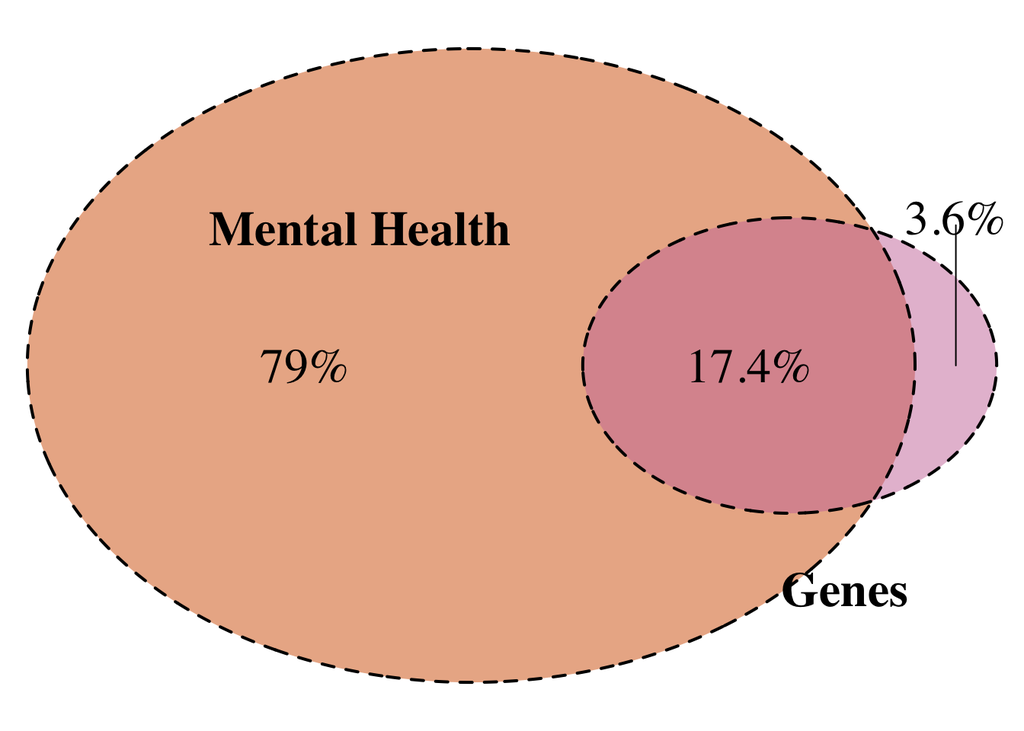

```r
venn_plot_baseline_psy_gene_percent <- draw.pairwise.venn(
  area1 =baseline_psy_gene_vec_corrected_percent[1]+baseline_psy_gene_vec_corrected_percent[3],
  area2 = baseline_psy_gene_vec_corrected_percent[2]+baseline_psy_gene_vec_corrected_percent[3],
  cross.area  = baseline_psy_gene_vec_corrected_percent[3],
  category = c("Genes", "Mental Health"),
  fill = c("#CC79A7", "#D55E00"),
  lty = "dashed",
  cat.col = c("black", "black"),
  filename = NULL,
  cex = 2, ## label font size
  cat.cex = 2,### caption font size
  lwd = 2,
  cat.fontface = "bold",
 cat.dist = c(0.05, -0.1), # Modified
  cat.pos = c(-10, 150),# Modified
  print.mode="percent")
```

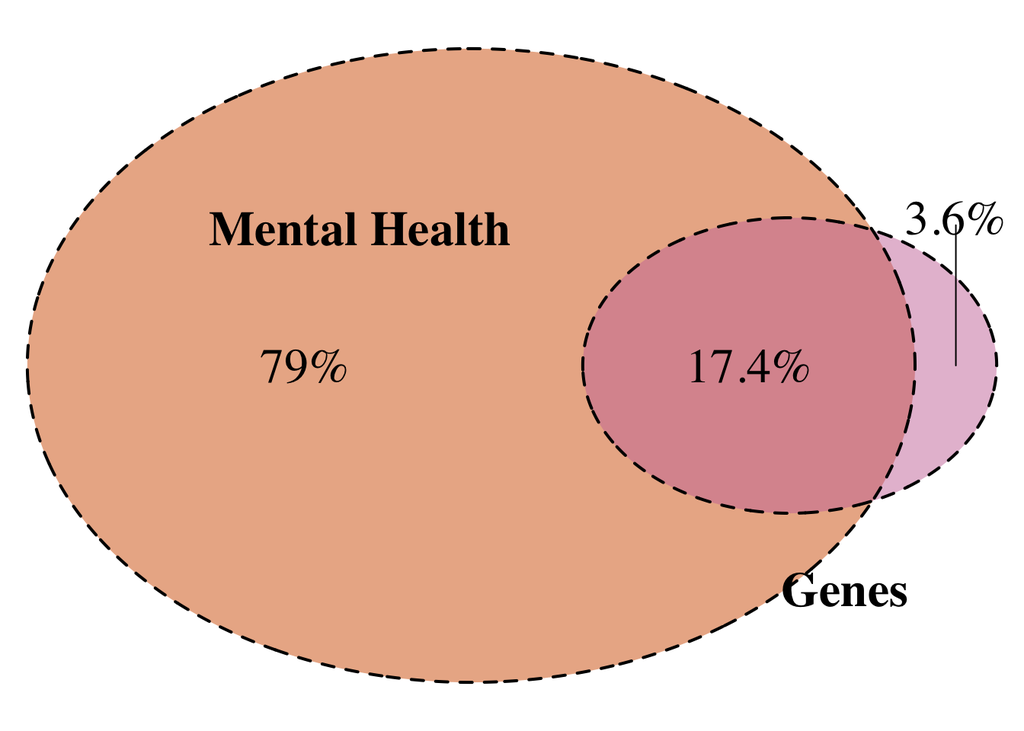

```r
grid.newpage()

grid::grid.draw(venn_plot_baseline_psy_gene_percent)
```

```r
#invisible(dev.off())
```

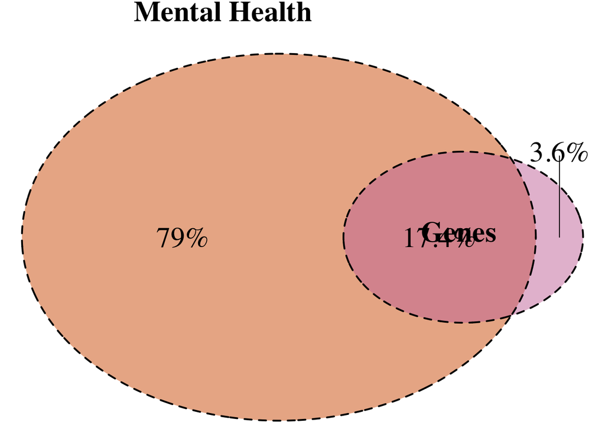

```r
venn_plot_baseline_psy_gene_percent_trial <- draw.pairwise.venn(
  area1 =baseline_psy_gene_vec_corrected_percent[2]+baseline_psy_gene_vec_corrected_percent[3],
  area2 = baseline_psy_gene_vec_corrected_percent[1]+baseline_psy_gene_vec_corrected_percent[3],
  cross.area  = baseline_psy_gene_vec_corrected_percent[3],
  category = c("Mental Health","Genes" ),
  fill = c("#D55E00","#CC79A7"),
  lty = "dashed",
  cat.col = c("black", "black"),
  filename = NULL,
  cex = 2, ## label font size
  cat.cex = 2,### caption font size
  lwd = 2,
  cat.fontface = "bold",
 cat.dist = c(0.05, -0.1), # Modified
  cat.pos = c(-10, 150),# Modified
  print.mode="percent")
```

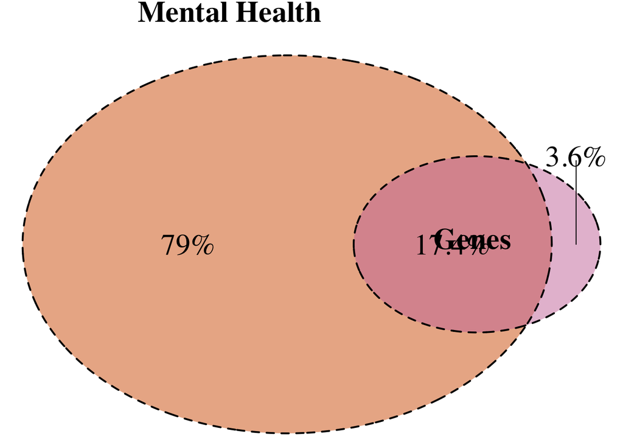

```r
grid.newpage()

grid::grid.draw(venn_plot_baseline_psy_gene_percent_trial)
```

```r
#invisible(dev.off())
```

Plot the raw score plot.

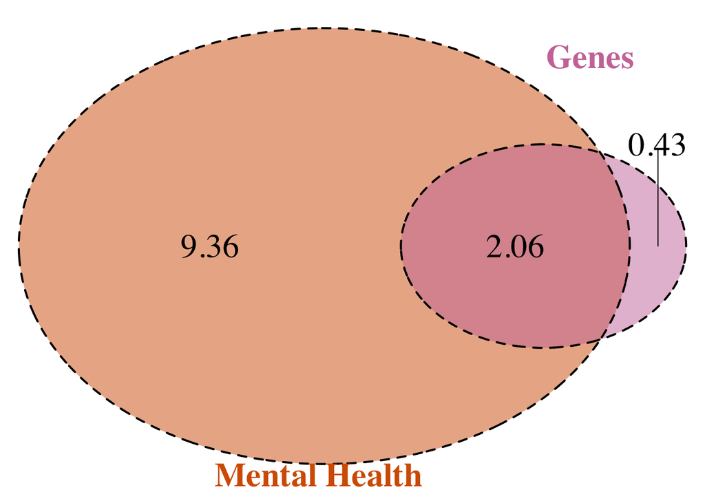

```r
venn_plot_baseline_pls_gene_raw <- draw.pairwise.venn(
  area1 =baseline_psy_gene_vec_corrected_raw[1]+baseline_psy_gene_vec_corrected_raw[3],
  area2 = baseline_psy_gene_vec_corrected_raw[2]+baseline_psy_gene_vec_corrected_raw[3],
  cross.area  = baseline_psy_gene_vec_corrected_raw[3],
  category = c("Genes", "Mental Health"),
  fill = c("#CC79A7", "#D55E00"),
  lty = "dashed",
  cat.col = c("#CC79A7", "#D55E00"),
  filename = NULL,
  cex = 2, ## label font size
  cat.cex = 2,### caption font size
  lwd = 2,
  cat.fontface = "bold",
  cat.dist = c(-0.27, 0.01), # Modified
  cat.pos = c(10, 1),# Modified
  #print.mode="percent"
  )
```

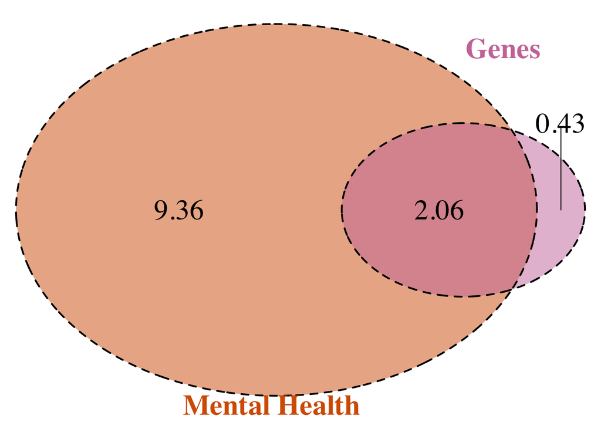

```r
grid.newpage()

grid::grid.draw(venn_plot_baseline_pls_gene_raw)
```

```r
#invisible(dev.off())
```

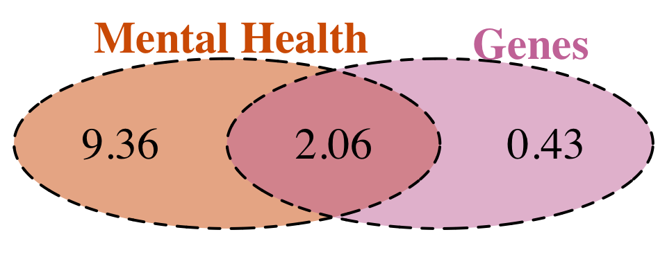

```r
venn_plot_baseline_pls_gene_raw <- draw.pairwise.venn(
  area1 =baseline_psy_gene_vec_corrected_raw[1]+baseline_psy_gene_vec_corrected_raw[3],
  area2 = baseline_psy_gene_vec_corrected_raw[2]+baseline_psy_gene_vec_corrected_raw[3],
  cross.area  = baseline_psy_gene_vec_corrected_raw[3],
  category = c("Genes", "Mental Health"),
  fill = c("#CC79A7", "#D55E00"),
  lty = "dashed",
  cat.col = c("#CC79A7", "#D55E00"),
  filename = NULL,
  cex = 2, ## label font size
  cat.cex = 2,### caption font size
  lwd = 2,
  cat.fontface = "bold",
  cat.dist = c(0.05, 0.05), # Modified
  cat.pos = c(20, 1),# Modified
  scaled = FALSE
  #print.mode="percent"
  )
```

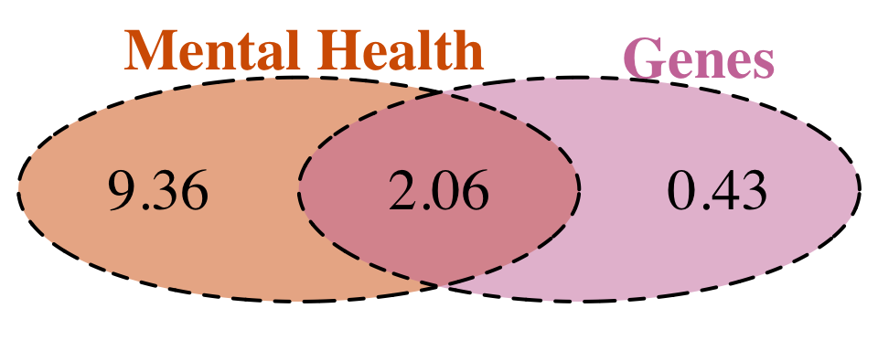

```r
grid.newpage()

grid::grid.draw(venn_plot_baseline_pls_gene_raw)
```

```r
#invisible(dev.off())
```

### 3.2.3 venn diagram for followup

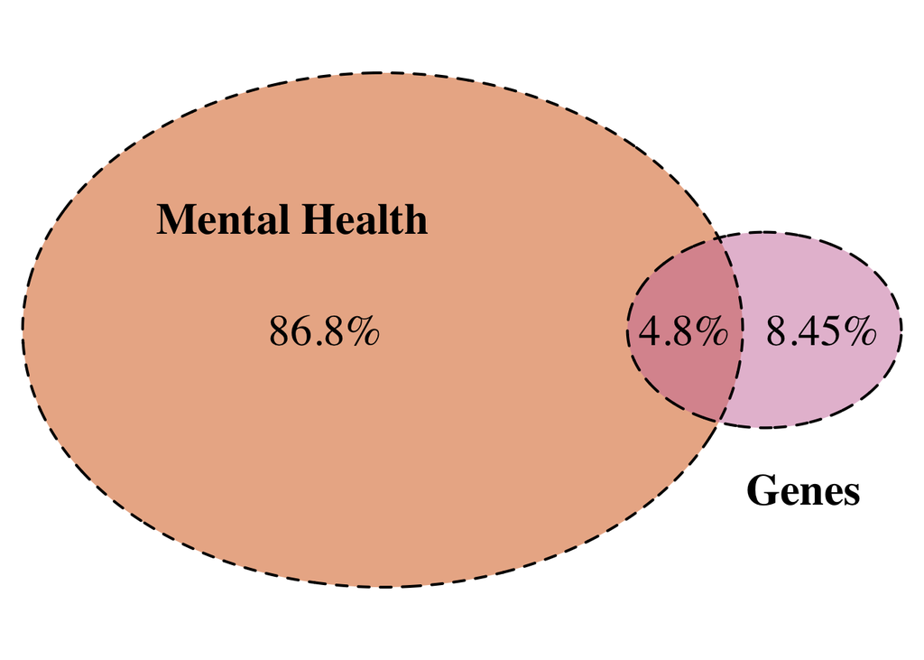

```r
venn_plot_psy_gene_followup_percent <- draw.pairwise.venn(
  area1 =psy_brain_vec_corrected_followup_percent[1]+psy_brain_vec_corrected_followup_percent[3],
  area2 = psy_brain_vec_corrected_followup_percent[2]+psy_brain_vec_corrected_followup_percent[3],
  cross.area  = psy_brain_vec_corrected_followup_percent[3],
  category = c("Genes", "Mental Health"),
  fill = c("#CC79A7", "#D55E00"),
  lty = "dashed",
  cat.col = c("black", "black"),
  filename = NULL,
  cex = 2, ## label font size
  cat.cex = 2,### caption font size
  lwd = 2,
  cat.fontface = "bold",
 cat.dist = c(0.05, -0.1), # Modified
  cat.pos = c(-10, 150),# Modified
  print.mode="percent"
  )
```

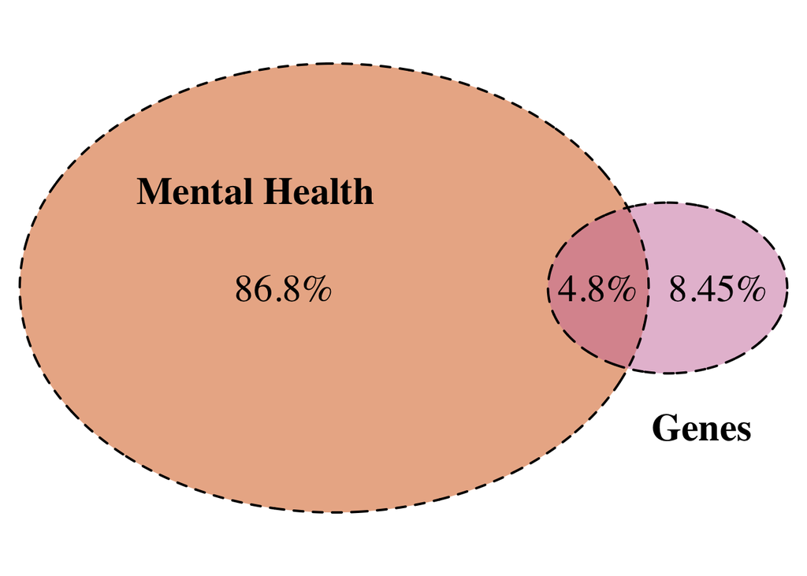

```r
grid.newpage()

grid::grid.draw(venn_plot_psy_gene_followup_percent)
```

```r
#invisible(dev.off())
```

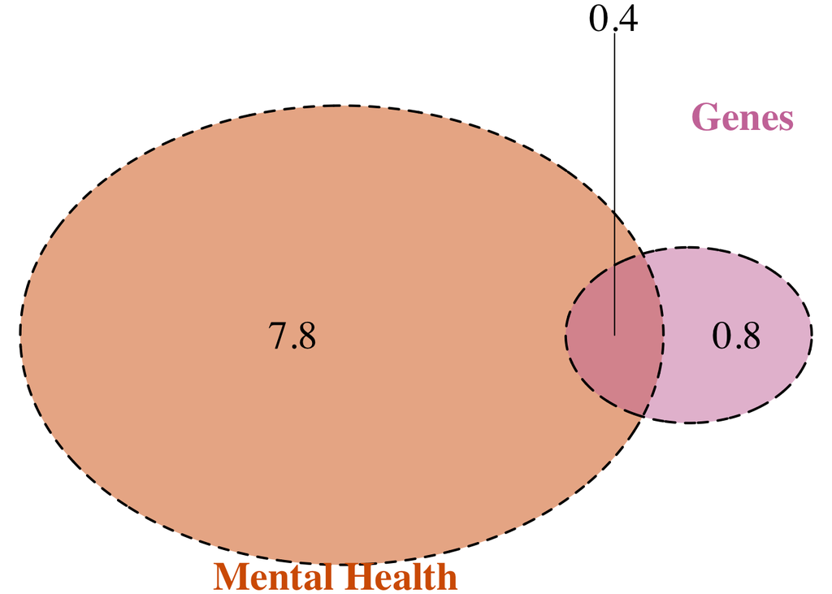

```r
venn_plot_psy_gene_followup_raw <- draw.pairwise.venn(
  area1 =psy_brain_vec_corrected_followup_raw[1]+psy_brain_vec_corrected_followup_raw[3],
  area2 = psy_brain_vec_corrected_followup_raw[2]+psy_brain_vec_corrected_followup_raw[3],
  cross.area  = psy_brain_vec_corrected_followup_raw[3],
  category = c("Genes", "Mental Health"),
  fill = c("#CC79A7", "#D55E00"),
  lty = "dashed",
  cat.col = c("#CC79A7", "#D55E00"),
  filename = NULL,
  cex = 2, ## label font size
  cat.cex = 2,### caption font size
  lwd = 2,
  cat.fontface = "bold",
  cat.dist = c(-0.27, 0.01), # Modified
  cat.pos = c(10, 1)# Modified
  #print.mode="percent"
  )
```

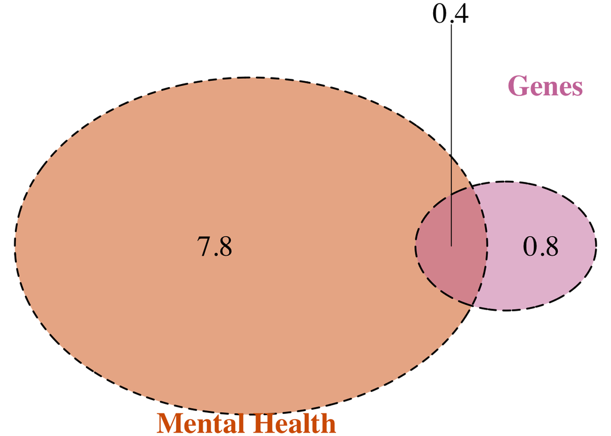

```r
grid.newpage()

grid::grid.draw(venn_plot_psy_gene_followup_raw)
```

```r
#invisible(dev.off())
```

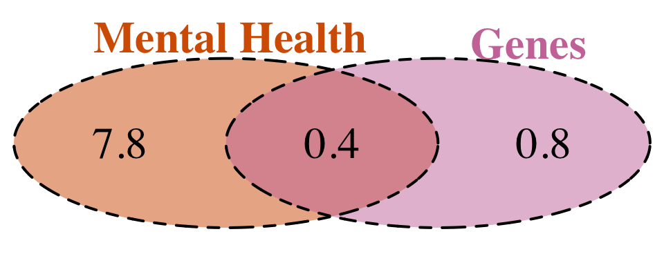

```r
venn_plot_psy_gene_followup_raw <- draw.pairwise.venn(
  area1 =psy_brain_vec_corrected_followup_raw[1]+psy_brain_vec_corrected_followup_raw[3],
  area2 = psy_brain_vec_corrected_followup_raw[2]+psy_brain_vec_corrected_followup_raw[3],
  cross.area  = psy_brain_vec_corrected_followup_raw[3],
  category = c("Genes", "Mental Health"),
  fill = c("#CC79A7", "#D55E00"),
  lty = "dashed",
  cat.col = c("#CC79A7", "#D55E00"),
  filename = NULL,
  cex = 2, ## label font size
  cat.cex = 2,### caption font size
  lwd = 2,
  cat.fontface = "bold",
  cat.dist = c(0.05, 0.05), # Modified
  cat.pos = c(20, 1),# Modified
  scaled = FALSE
  #print.mode="percent"
  )
```

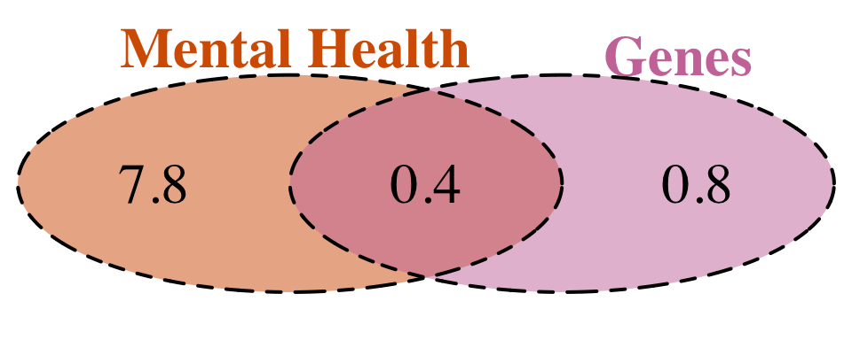

```r
grid.newpage()

grid::grid.draw(venn_plot_psy_gene_followup_raw)
```

```r
#invisible(dev.off())
```

## 3.3 Print mixed model output

Linear mixed models at baseline:

```r
### model with gene and mental health

tab_model(common_analysis_psy_gene_all$psy_gene_model,
          common_analysis_psy_gene_all$psy_model,
          common_analysis_psy_gene_all$gene_model)
```

|  | gfactor |  |  | gfactor |  |  | gfactor |  |  |
| --- | --- | --- | --- | --- | --- | --- | --- | --- | --- |
| Predictors | Estimates | CI | p | Estimates | CI | p | Estimates | CI | p |
| (Intercept) | 0.23 | 0.21 – 0.26 | **<0.001** | 0.23 | 0.21 – 0.25 | **<0.001** | 0.23 | 0.21 – 0.26 | **<0.001** |
| mental savg | 0.07 | 0.03 – 0.11 | **0.001** | 0.14 | 0.11 – 0.16 | **<0.001** |  |  |  |
| mental cws | 0.28 | 0.26 – 0.30 | **<0.001** | 0.28 | 0.26 – 0.31 | **<0.001** |  |  |  |
| gene savg favg | -0.07 | -0.11 – -0.03 | **0.001** |  |  |  | -0.13 | -0.15 – -0.10 | **<0.001** |
| gene cws cwf | 0.05 | 0.03 – 0.07 | **<0.001** |  |  |  | 0.05 | 0.03 – 0.07 | **<0.001** |
| Random Effects |  |  |  |  |  |  |  |  |  |
| σ<sup>2</sup> | 0.49 |  |  | 0.50 |  |  | 0.53 |  |  |
| τ<sub>00</sub> | 0.27 <sub>SITE_ID_L:REL_FAMILY_ID</sub> |  |  | 0.26 <sub>SITE_ID_L:REL_FAMILY_ID</sub> |  |  | 0.32 <sub>SITE_ID_L:REL_FAMILY_ID</sub> |  |  |
| ICC | 0.35 |  |  | 0.34 |  |  | 0.37 |  |  |
| N | 21 <sub>SITE_ID_L</sub> |  |  | 21 <sub>SITE_ID_L</sub> |  |  | 21 <sub>SITE_ID_L</sub> |  |  |
|  | 4751 <sub>REL_FAMILY_ID</sub> |  |  | 4751 <sub>REL_FAMILY_ID</sub> |  |  | 4751 <sub>REL_FAMILY_ID</sub> |  |  |
| Observations | 5779 |  |  | 5779 |  |  | 5779 |  |  |
| Marginal R<sup>2</sup> / Conditional R<sup>2</sup> | 0.118 / 0.428 |  |  | 0.114 / 0.417 |  |  | 0.025 / 0.388 |  |  |

Linear mixed models at followup

```r
tab_model(common_analysis_psy_gene_all_followup$psy_gene_model,
          common_analysis_psy_gene_all_followup$psy_model,
          common_analysis_psy_gene_all_followup$gene_model)
```

|  | gfactor |  |  | gfactor |  |  | gfactor |  |  |
| --- | --- | --- | --- | --- | --- | --- | --- | --- | --- |
| Predictors | Estimates | CI | p | Estimates | CI | p | Estimates | CI | p |
| (Intercept) | 1.06 | 1.03 – 1.08 | **<0.001** | 1.06 | 1.03 – 1.08 | **<0.001** | 1.06 | 1.03 – 1.09 | **<0.001** |
| mental savg | 0.02 | -0.01 – 0.06 | 0.150 | 0.06 | 0.03 – 0.09 | **<0.001** |  |  |  |
| mental cws | 0.25 | 0.22 – 0.28 | **<0.001** | 0.25 | 0.22 – 0.28 | **<0.001** |  |  |  |
| gene savg favg | -0.07 | -0.10 – -0.03 | **<0.001** |  |  |  | -0.08 | -0.11 – -0.05 | **<0.001** |
| gene cws cwf | 0.05 | 0.03 – 0.07 | **<0.001** |  |  |  | 0.05 | 0.03 – 0.07 | **<0.001** |
| Random Effects |  |  |  |  |  |  |  |  |  |
| σ<sup>2</sup> | 0.41 |  |  | 0.42 |  |  | 0.42 |  |  |
| τ<sub>00</sub> | 0.32 <sub>SITE_ID_L:REL_FAMILY_ID</sub> |  |  | 0.31 <sub>SITE_ID_L:REL_FAMILY_ID</sub> |  |  | 0.37 <sub>SITE_ID_L:REL_FAMILY_ID</sub> |  |  |
| ICC | 0.44 |  |  | 0.43 |  |  | 0.47 |  |  |
| N | 21 <sub>SITE_ID_L</sub> |  |  | 21 <sub>SITE_ID_L</sub> |  |  | 21 <sub>SITE_ID_L</sub> |  |  |
|  | 3242 <sub>REL_FAMILY_ID</sub> |  |  | 3242 <sub>REL_FAMILY_ID</sub> |  |  | 3242 <sub>REL_FAMILY_ID</sub> |  |  |
| Observations | 3881 |  |  | 3881 |  |  | 3881 |  |  |
| Marginal R<sup>2</sup> / Conditional R<sup>2</sup> | 0.090 / 0.489 |  |  | 0.082 / 0.474 |  |  | 0.012 / 0.475 |  |  |